# Ranking TOP 10 Players From 2019-2020 season Using Linear Regression

Using their points per game from the last four seasons from the top point producers in the 2019-2020 NHL season, we will use linear regression to see how they perform this year.

Leon Draisaitl:

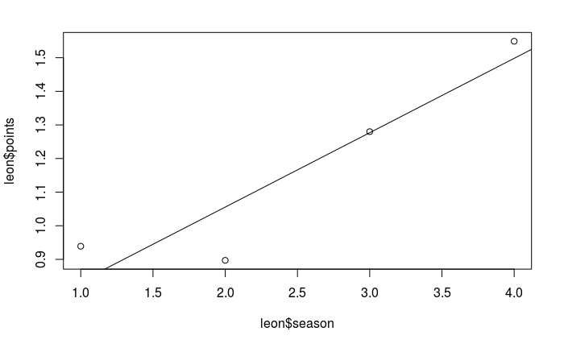

```r
points <- c(0.939, 0.897, 1.280, 1.549)
season <- c(1, 2, 3, 4)
leon <- data.frame(season, points)
# plot a scatter plot
plot(leon$season, leon$points)
# simple linear regression
r <- lm(points~season, data=leon)
# add the regression line
abline(r)
```

```r
# predict points per game for the fifth season
 ld = predict(r, list(season=5))
 ld
```

```
     1
1.7195
```

We can expect Leon Draisaitl to have a Points per game of 1.7195 this season.

Connor Mcdavid:

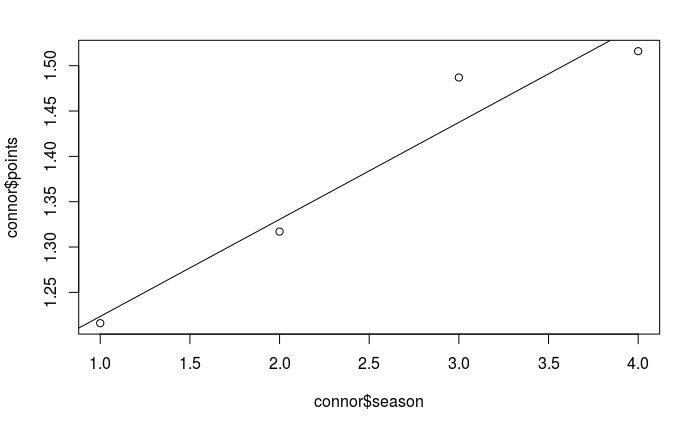

```r
points <- c(1.216, 1.317, 1.487, 1.516)
season <- c(1, 2, 3, 4)
connor <- data.frame(season, points)
# plot a scatter plot
plot(connor$season, connor$points)
# simple linear regression
r <- lm(points~season, data=connor)
# add the regression line
abline(r)
```

```r
# predict points per game for the fifth season
cm = predict(r, list(season=5))
cm
```

```
     1
1.6515
```

We can expect Connor Mcdavid to have a Points per game of 1.6515 this season.

David Pastranak:

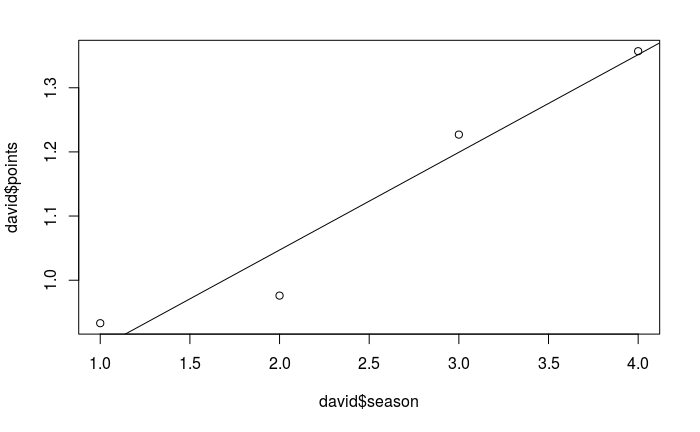

```r
points <- c(0.933, 0.976, 1.227, 1.357)
season <- c(1, 2, 3, 4)
david<- data.frame(season, points)
# plot a scatter plot
plot(david$season, david$points)
# simple linear regression
r <- lm(points~season, data=david)
# add the regression line
abline(r)
```

```r
# predict points per game for the fifth season
dp = predict(r, list(season=5))
dp
```

```
    1
1.504
```

we can expect David pastranak to have a Points per game of 1.504 this season.

Artemi Panarin:

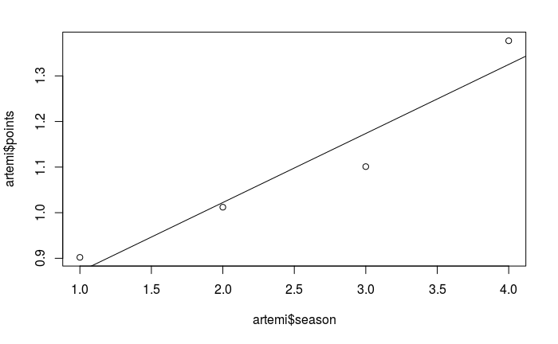

```r
points <- c(0.902, 1.012, 1.101, 1.377)
season <- c(1, 2, 3, 4)
artemi<- data.frame(season, points)
# plot a scatter plot
plot(artemi$season, artemi$points)
# simple linear regression
r <- lm(points~season, data=artemi)
# add the regression line
abline(r)
```

```r
# predict points per game for the fifth season
ap = predict(r, list(season=5))
ap
```

```
     1
1.4765
```

we can expect Artemi panarin to have a points per game of 1.4765 this season.

Nathan MacKinnon:

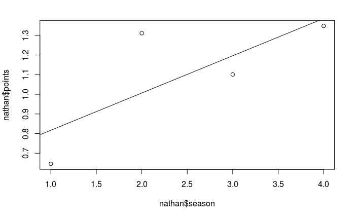

```r
points <- c(0.646, 1.311, 1.101, 1.348)
season <- c(1, 2, 3, 4)
nathan<- data.frame(season, points)
# plot a scatter plot
plot(nathan$season, nathan$points)
# simple linear regression
r <- lm(points~season, data=nathan)
# add the regression line
abline(r)
```

```r
# predict points per game for the fifth season
nm = predict(r, list(season=5))
nm
```

```
     1
1.5755
```

we can expect Nathan MacKinnon to have a points per game of 1.5755 this season.

Brad Marchand:

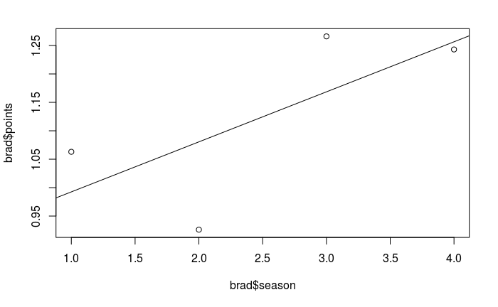

```r
points <- c(1.063, 0.926, 1.266, 1.243)
season <- c(1, 2, 3, 4)
brad<- data.frame(season, points)
# plot a scatter plot
plot(brad$season, brad$points)
# simple linear regression
r <- lm(points~season, data=brad)
# add the regression line
abline(r)
```

```r
# predict points per game for the fifth season
bm = predict(r, list(season=5))
bm
```

```
     1
1.3445
```

we can expect Brad Marchand to have a points per game of 1.3445 this season.

Nikita Kucherov:

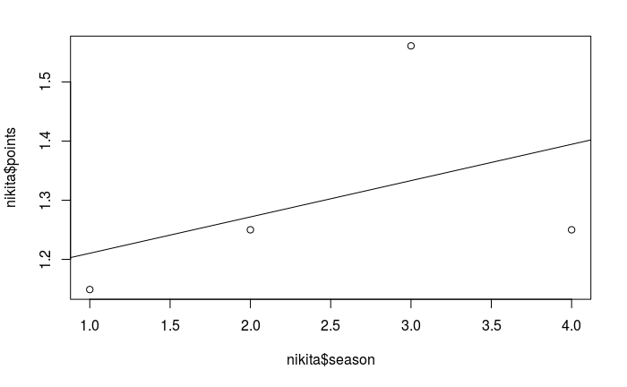

```r
points <- c(1.149, 1.25, 1.561, 1.25)
season <- c(1, 2, 3, 4)
nikita<- data.frame(season, points)
# plot a scatter plot
plot(nikita$season, nikita$points)
# simple linear regression
r <- lm(points~season, data=nikita)
# add the regression line
abline(r)
```

```r
# predict points per game for the fifth season
nk = predict(r, list(season=5))
nk
```

```
    1
1.456
```

we can expect Nikita Kucherov to have a points per game of 1.456 this season.

Patrick Kane

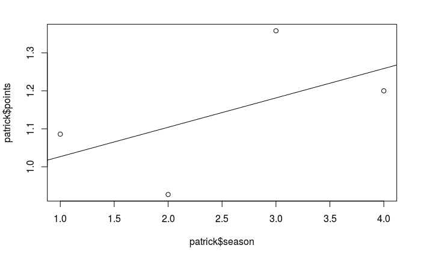

```r
points <- c(1.086, 0.927, 1.358, 1.2)
season <- c(1, 2, 3, 4)
patrick<- data.frame(season, points)
# plot a scatter plot
plot(patrick$season, patrick$points)
# simple linear regression
r <- lm(points~season, data=patrick)
# add the regression line
abline(r)
```

```r
# predict points per game for the fifth season
pk = predict(r, list(season=5))
pk
```

```
    1
1.336
```

we Can expect Patrick Kane to have a points per game of 1.336 this season.

Auston Matthews:

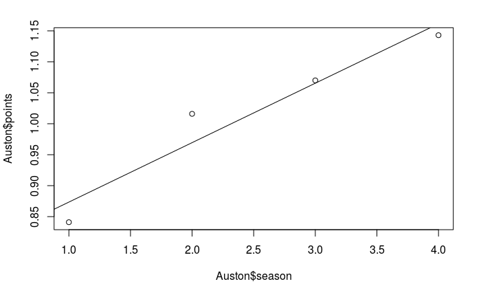

```r
points <- c(0.841, 1.016, 1.07, 1.143)
season <- c(1, 2, 3, 4)
Auston<- data.frame(season, points)
# plot a scatter plot
plot(Auston$season, Auston$points)
# simple linear regression
r <- lm(points~season, data=Auston)
# add the regression line
abline(r)
```

```r
# predict points per game for the fifth season
am = predict(r, list(season=5))
am
```

```
     1
1.2575
```

we can predict Auston Matthews to have a points per game of 1.2575 this season.

Jack Eichel:

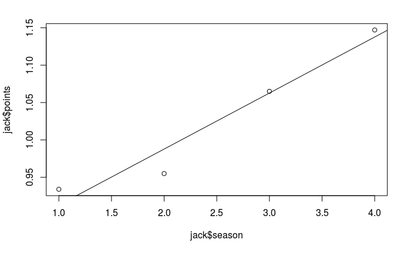

```r
points <- c(0.934, 0.955, 1.065, 1.147)
season <- c(1, 2, 3, 4)
jack<- data.frame(season, points)
# plot a scatter plot
plot(jack$season, jack$points)
# simple linear regression
r <- lm(points~season, data=jack)
# add the regression line
abline(r)
```

```r
# predict points per game for the fifth season
je = predict(r, list(season=5))
je
```

```
     1
1.2125
```

We can expect Jack Eichel to have a points her game of 1.2125 this season.

Because of Covid-19, there will be 56 regular season games in the 2021 season. Here, I have ranked the number of points these players should have this season predicted using linear regression:

```r
player <- c("Leon Draisaitl", "Connor Mcdavid", "Nathan MacKinnon", "David Pastanak", "Artemi Panarin", "Nikita Kucherov", "Brad Marchand", "Patrick Kane", "Auston Matthews", "Jack Eichel")
total_points <- c(ld*56, cm*56, nm*56, dp*56, ap*56, nk*56, bm*56, pk*56, am*56, je*56)
final <- data.frame(player, total_points)
final
```

| player | total_points |
| --- | --- |
| Leon Draisaitl | 96.292 |
| Connor Mcdavid | 92.484 |
| Nathan MacKinnon | 88.228 |
| David Pastanak | 84.224 |
| Artemi Panarin | 82.684 |
| Nikita Kucherov | 81.536 |
| Brad Marchand | 75.292 |
| Patrick Kane | 74.816 |
| Auston Matthews | 70.420 |
| Jack Eichel | 67.900 |